# 자연언어처리 13주차_기계학습을 사용한 자연언어처리 #5: 비지도학습 - 차원축소 및 군집화

고려대학교 일반대학원 심리학과

2022년 11월 28일 월요일 6-7교시

# 1. 비지도학습 I: 차원축소 - 주성분분석(principal components analysis, PCA)

- 정의
  - 데이터의 원래 분산을 가능한 한 보존하면서 차원을 축소해주는 기법.
  - *n* 개의 관찰값이 *p* 차원 공간에 존재하지만, 모든 차원이 동등하게 중요한 것은 아님. PCA에서는 가능한 한 중요한 더 작은 수의 차원들을 찾아내는 데 목적을 둠. 여기서 “중요하다”는 관찰값들이 각 차원을 따라 변화하는 양(즉 분산)을 통해 측정.
  - PCA를 통해 찾아낸 새로운 차원들은 원래의 *p* 예측변수들의 선형조합에 해당.
  - 최종목표: 원 데이터에 포함된 정보를 최대한 많이 보존한 채 예측변수들에 대한 선형조합 서브셋을 사용하여 모형예측의 정확도와 효율성을 높이는 것!

## (1) 준비사항

- 차원축소를 위한 데이터의 조건
  - 데이터가 tidy 형식이어야 함.
  - 결측값이 제거 또는 대체되어야 함.
  - 데이터는 모두 수치형 변수여야 함(범주형 변수는 원핫 또는 더미 변수로 변환).
  - 수치형 변수는 변수 간 비교를 위해 모두 표준화되어야 함.
- `my_basket`: 어느 마트에서 이루어진 2000건의 거래를 기록한 데이터셋.

```r
# 모형수립 과정에 사용되는 주요 패키지.
library(tidyverse) # 데이터 조작 및 시각화용.
library(tidymodels) # 데이터 전처리 및 모형 훈련용.
library(h2o) # 차원축소용.
# 시범용 데이터셋
url <- "https://koalaverse.github.io/homlr/data/my_basket.csv"
my_basket <- read_csv(url)
dim(my_basket)
```

```
## [1] 2000   42
```

## (2) 기본개념

**[그림 1] 서로 상관된 `my_basket` 데이터 변수들**

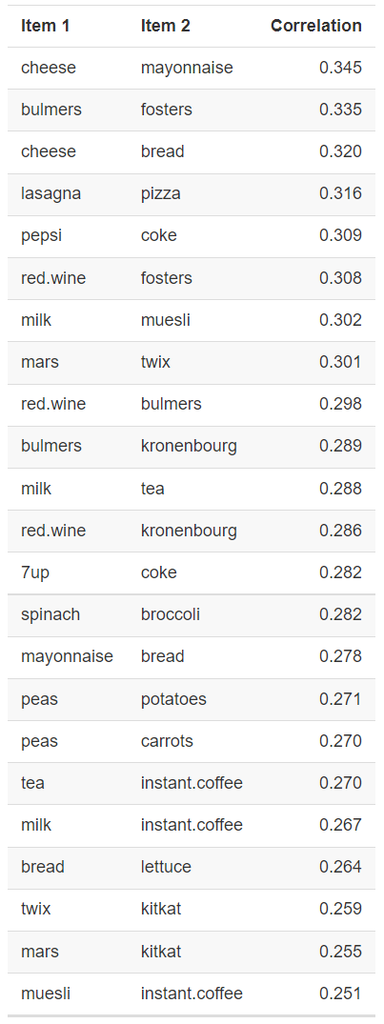

- 이처럼 속성이 유사한 변수들은 원 데이터보다 낮은 차원으로 설명할 수 있기를 원함. 콜라, 펩시, 7UP 같은 탄산음료는 한꺼번에 구매하는 경우가 많음. $\Rightarrow$ 이들 변수는 하나의 **잠재변수**(*latent variable*)인 “탄산음료”로 축소할 수 있음.
- 장점
  - 데이터셋의 많은 예측변수들을 좀 더 효율적으로 기술할 수 있음.
  - 예측변수 간 다중공선성을 제거할 수 있음.
  - 축소된 변수들을 향후 지도학습 모형에 투입 시 예측 정확도의 향상을 기대할 수 있음.
- 더 낮은 차원으로 묶일 수 있는 변수 파악하는 방법
  1. 변수들 간의 공변량(covariance: 분산이 함께 변해가는 정도)를 조사.
  2. 변수들을 상관이 없는 변수들의 더 작은 세트로 묶어냄.
  3. 차원축소로 새롭게 탄생한 변수들을 **주성분**(*principal components*, PCs)이라고 부름.
  4. 축소된 변수 세트가 완전체 변수 세트가 지닌 분산의 많은 부분을 설명해줄 수도록 차원이 잘 축소된 것.
  5. 주성분을 생성하는 데 사용된 가중치(weights)는 원래 예측변수들이 새로운 주성분에 상대적으로 얼마나 기여하는가를 나타냄.
- 분산의 보존

**[그림 2] 2차원 데이터셋의 3개 초평면 후보[^1]**

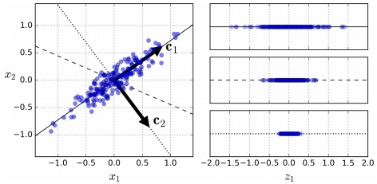

- [그림 2] 해석
  - 저차원의 초평면에 데이터 포인트들을 투영하게 되면 차원이 줄어듦.
  - 이때 3개의 축이 초평면 후보라면, 실선, 작은 점선, 큰 점선 중 실선($C_1$)을 선택하는 것이 데이터 포인트들의 분산을 최대로 보존하는 것이고, 작은 점선($C_2$)을 선택하는 것이 분산을 가장 적게 보존하는 방법임.
  - 분산을 최대로 보존할 수 있는 축을 선택할 때 데이터셋의 정보손실을 가장 잘 막아낼 수 있을 것. 분산이 커야 데이터 포인트 간의 차이점이 명확해지고, 이는 우리 모형의 정확도를 높이는 데 도움을 줌.

## (3) 주성분 찾기

- 첫 번째 주성분
  - 예측변수 $X_1, X_1, ..., X_p$의 첫 번째 주성분은 변수들의 선형조합이면서 가장 큰 분산을 지니는 $Z_{1} = \phi_{11}X_{1} + \phi_{21}X_{2} + ... + \phi_{p1}X_{p}$임.
  - 여기서 $\phi_1 = \left(\phi_{11}, \phi_{21}, \dots, \phi_{p1}\right)$은 첫 번째 주성분의 부하 벡터(loading vector)이며, $\phi$는 정규화되어 있으므로, $\sum_{j=1}^{p}{\phi_{j1}^{2}} = 1$임.
- 두 번째 주성분
  - $Z_{1}$이 결정되면, 이 첫 번째 축에 직교하고 남은 분산을 최대한 보존하는 두 번째 주성분 $Z_{2}$를 찾을 수 있음. 두 번째 주성분은 $Z_{1}$과는 **상관이 없는** $X_1, \dots , X_p$의 선형조합이면서 가장 큰 분산을 지니는 $Z_{2} = \phi_{12}X_{1} + \phi_{22}X_{2} + ... + \phi_{p2}X_{p}$임.
  - 여기서 $\phi_2 = \left(\phi_{12}, \phi_{22}, \dots, \phi_{p2}\right)$는 두 번째 주성분의 부하 벡터로 정의됨.
- 이러한 과정은 모든 *p* 개의 주성분이 계산될 때까지 진행됨.
- 이렇듯 *p* 번째 축을 정의하는 단위 벡터를 *p* 번째 주성분이라고 함. [그림 2]에서 첫 번째 주성분은 $C_1$이고, 두 번째 주성분은 $C_2$임.

**[그림 4] 2차원일 때의 PCA 사례[^3]**

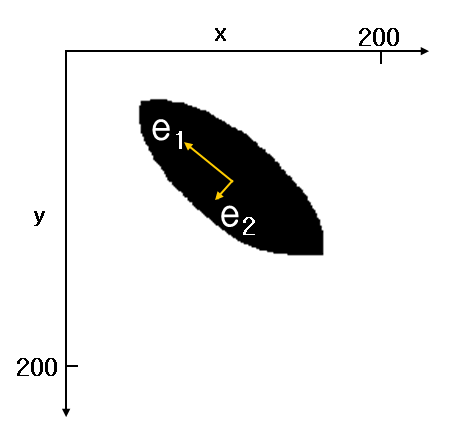

- [그림 4] 해석
  - 2차원 좌표평면에 *n*개의 데이터가 타원형으로 분포되어 있을 때, 이 데이터 포인트들의 분포특성을 2개의 벡터로 가장 잘 설명할 수 있는 방법은 무엇일까?
    - $\Rightarrow$ $e_1$과 $e_2$ 2개의 벡터로 데이터 분포를 설명하는 것.
    - $e_1$ 및 $e_2$의 방향과 크기를 알면 해당 데이터의 분포가 어떤 양상을 띠는지 효율적으로 파악 가능.
  - PCA
    - 데이터 포인트 하나하나가 아닌, 여러 데이터 포인트가 모여 하나의 분포를 이를 때 이 분포를 구성하는 주성분을 분석해주는 방법.
    - 주성분: 그 방향을 따라갔을 때 데이터 포인트들의 분산이 가장 큰 벡터. [그림 4]를 보면, $e_1$ 방향을 따라갔을 때 데이터 포인트들의 분산이 가장 큰 것을 알 수 있음.
    - 2차원 데이터셋에 대해 PCA를 수행하면 2개의 서로 수직인 주성분 벡터를 찾아주고, [그림 5]과 같이 3차원 데이터셋에 대해 PCA를 수행하면 3개의 서로 수직인 주성분 벡터를 찾아줌.

**[그림 5] 3차원일 때의 PCA 사례[^4]**

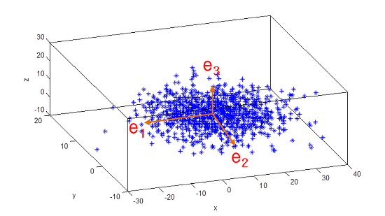

- [그림 6] 해석
  - 두 개의 예측변수가 0.56이라는 상관을 지니고 있다고 가정.이들 변수의 공분산(covariation)을 두 개의 차원(PC1, PC2)로 설명할 수 있음.
  - 가장 큰 공분산은 첫 번째 주성분을 따라 형성됨. $\Rightarrow$ 각각의 데이터 포인트가 수직으로 투영(projection)되었을 때 데이터 포인트와의 총 거리 제곱을 최소화해주는 선분이 바로 그것!
  - 결과적으로, 첫 번째 주성분을 사용하여 예측변수 1과 예측변수 2 간 공변량의 대부분(93퍼센트)를 설명할 수 있음.

**[그림 6] 상관이 0.56인 두 예측변수의 주성분**

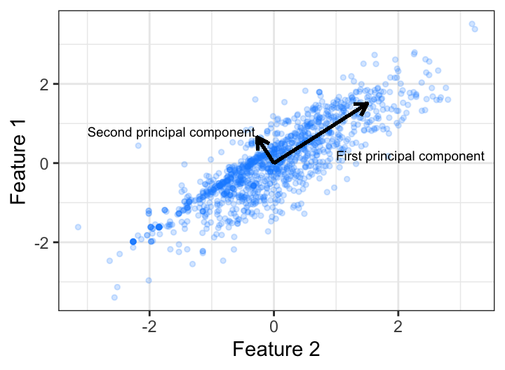

## (4) PCA 실행하기

- **h2o** 패키지 사용
  - 다양한 차원축소 방법 제공.
  - 데이터 전처리 과정(수치형 변수 표준화, 결측값 대체, 범주형 변수 인코딩 등)를 자동으로 해줌.

```r
# h2o 준비작업.
h2o.no_progress()  # 진행상황 바 끄기 turn off progress bars for brevity
h2o.init(max_mem_size = "5g") # h2o를 초기화하고 R과 h2o를 연결하기. h2o에 메모리를 최대 얼마까지 할당할 것인지 설정. 여기서는 5기가.
```

[output not shown]

- 모형 훈련용 함수
  - `as.h2o()`: **h2o** 객체로 변환해줌.
  - `h2o.prcomp()` 함수의 주요 논항
    - `training_frame`: 훈련용 데이터.
    - `pca_method`: 어떤 주성분 방법을 사용할 것인지 정하기. 주성분을 계산하는 몇 가지 방법이 존재.
      - 선택지: “GramSVD”, “Power”, “Randomized”, “GLRM.”
      - 데이터가 대부분 수치형 변수로 구성 시: `pca_method = "GramSVD"` 사용.
      - 데이터에 범주형 변수가 다수 포함 시: `pca_method = "GLRM"` 사용.
  - `k`: 얼마나 많은 주성분을 계산할 것인지 정하기. 예측변수와 동일 수가 가장 좋음(뒤에서 실제로 사용할 주성분들을 가려내는 방법을 살펴보면서 어떻게 주성분의 수를 예측변수보다 줄이는지 알아볼 것).
  - `transform`: 내 데이터를 어떻게 표준화할 것인지 정하기. 선택지 $\Rightarrow$ “NONE”, “STANDARDIZE”, “NORMALIZE”, “DEMEAN”, “DESCALE.”
  - `impute_missing`: 결측값을 대체할 것인지 여부 정하기. 내 데이터에 결측값이 존재한다면 해당 칼럼의 평균으로 대체를 수행.
  - `max_runtime_secs`: 최대 수행시간(초). 데이터의 규모가 크다면 모형훈련을 위한 수행시간을 제한할 것.

```r
# 데이터를 h2o 객체로 변환하기
my_basket.h2o <- as.h2o(my_basket)

# PCA 수행하기.
my_pca <- h2o.prcomp(
  training_frame = my_basket.h2o,
  pca_method = "GramSVD",
  k = ncol(my_basket.h2o),
  transform = "STANDARDIZE",
  impute_missing = TRUE,
  max_runtime_secs = 1000
)
```

- 모형 훈련 후
  - `glimpse(my_pca)`: 모형에 대한 모든 정보를 한눈에 열람할 수 있음.
  - `my_pca@model$importance`: 개별 주성분, 개별 주성분의 표준편차, 개별 주성분으로 설명되는 분산의 누적비율 등의 중요한 정보가 포함되어 있음.
  - 첫 번째 주성분(PC1)이 가장 많은 분산을 포착하고 있으며, PC2, PC3가 그 뒤를 따름.
  - 부하량(loadings)을 평가하면 원래 예측변수 중 어느 것이 주성분에 기여하는지 파악할 수 있음. 앞서 기술했듯이, 첫 번째 주성분의 부하량은 $\phi_{11}, \phi_{21}, \dots, \phi_{p1}$으로 나타낼 수 있음. $\Rightarrow$ 따라서 이들 부하량은 각 예측변수가 연관된 주성분에 미치는 영향력을 나타낸다고 할 수 있음.
  - PC1의 부하량을 그래프로 나타내면, 가장 기여량이 큰 예측변수들은 대부분 알콜음료(사탕류, 담배, 복권는 음주와 관련!)임을 알 수 있음.

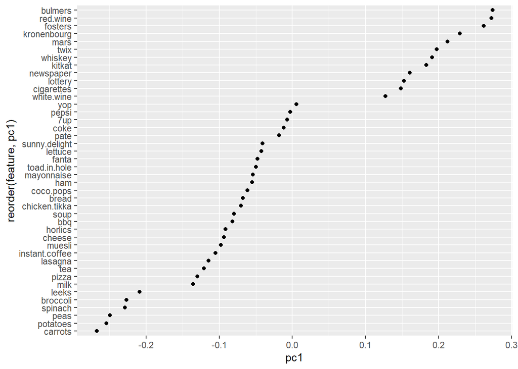

```r
# PC1의 부하량과 원래 예측변수 간의 관계 시각화하기.
my_pca@model$eigenvectors %>%  # 모형의 고유 벡터를 서브세팅함.
  as.data.frame() %>% # 데이터프레임 형식으로 변환.
  mutate(feature = row.names(.)) %>% # 행 이름을 feature(예측변수)라는 이름의 칼럼으로 만듦.
  ggplot(aes(pc1, reorder(feature, pc1))) + # x축은 PC1, y축은 feature(단 PC1의 크기에 따라 내림차순)으로 그래프 그리기.
  geom_point() # 데이터 포인트를 점으로 나타내기.
```

- 주성분 상호 비교하기
  - 그래프를 통해 다양한 예측변수들이 PC1과 PC2에 어떻게 기여하는지를 시각화할 수 있음.
  - 서로 구분되는 예측변수 집단들이 형성되어 있고, 어떻게 이들이 PC1과 PC2에 기여하는지를 확인할 수 있음.
  - 가령, 알콜음료(위스키, 와인 등)은 PC1에 긍정적으로 기여하는 반면, PC2에는 훨씬 작고 부정적인 영향을 미치는 것을 알 수 있음. $\Rightarrow$ 알콜음료 구입이 포함된 마트 거래의 경우, PC1의 평균값보다 크고, PC2의 평균값보다 작음을 의미.

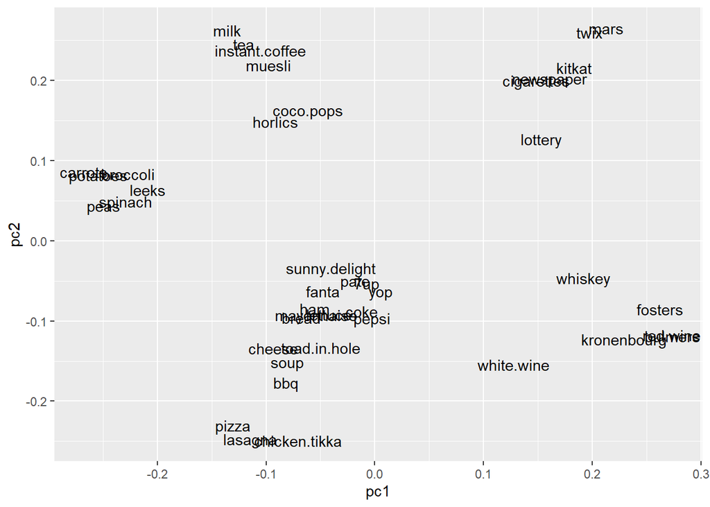

```r
# PC1과 PC2 부하량과 원래 예측변수 간의 관계 비교하기.
my_pca@model$eigenvectors %>%
  as.data.frame() %>%
  mutate(feature = row.names(.)) %>%
  ggplot(aes(pc1, pc2, label = feature)) +
  geom_text()
```

## (5) 주성분 수 선택하기

### (1) 고윳값(eigenvalue) 준거

- 고윳값 설명
  - 고윳값의 합 = PCA에 투입되는 변수들의 수.
  - 고윳값의 범위는 1보다 큰 값에서 0에 근사한 값까지 걸쳐 있음.
  - 고윳값 1은 해당 주성분이 하나의 변수가 차지하는 분산만큼을 설명하고 있음을 의미함.
  - 고윳값 준거: 각 성분이 최소 하나의 변수가 차지하는 분산 정도는 설명해주어야 함을 의미. 따라서 최소 1보다 큰 고윳값을 지닌 성분만 살아남을 수 있음.
- `h2o.prcomp()`
  - 자동으로 주성분의 표준편차(고윳값의 제곱근)를 계산해줌. $\Rightarrow$ 고윳값을 쉽게 계산하고 고윳값의 합이 1과 같거나 1보다 큰 주성분을 찾아낼 수 있음.
  - `my_basket` 데이터셋: 고윳값 준거에 따르면 해당 데이터셋의 첫 주성분 10개를 취할 수 있음([그림 7] 참조).

```r
# 고윳값 계산하기.
eigen <- my_pca@model$importance["Standard deviation", ] %>% # 표준편차만 서브세팅하기.
  unlist() %>% # 벡터로 변환하기.
  .^2 # 제곱하기.

# 모든 고윳값의 합 = 변수의 수.
sum(eigen)
```

```
## [1] 42
```

```r
# 고윳값의 합이 1과 같거나 1보다 큰 주성분 찾기.
which(eigen >= 1)
```

```
##  pc1  pc2  pc3  pc4  pc5  pc6  pc7  pc8  pc9 pc10
##    1    2    3    4    5    6    7    8    9   10
```

**[그림 7] 고윳값 준거 기반 주성분 수 선정: `my_basket` 데이터셋**

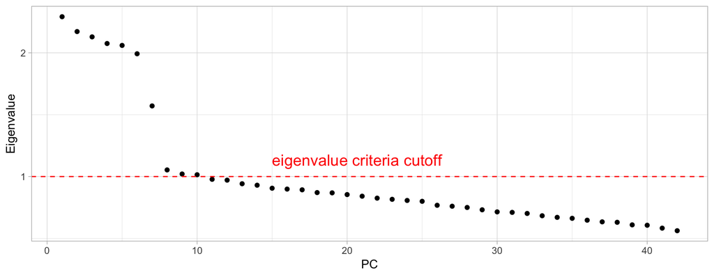

### (2) 주성분에 의해 설명되는 총 분산의 비율(proportion of variance explained, PVE) 준거

- PVE
  - 우리가 설명하고자 하는 총 분산을 바탕으로 한 주성분 수 선정 방법.
  - 공식: *m* 번째 주성분에 대한 PVE의 계산: $PVE = \frac{\sum_{i=1}^{n}(\sum_{j=1}^{p}{\phi_{jm}x_{ij}})^{2}}{\sum_{j=1}^{p}\sum_{i=1}^{n}{x_{ij}^{2}}}$
- `h2o.prcomp()`
  - PVE(주성분에 의해 설명되는 분산의 비율)과 CVE(cumulative variance explained: 주성분에 의해 설명되는 분산의 누적비율)를 모두 제공해줌.
  - 해당 정보를 추출하는 방법은 다음과 같음.

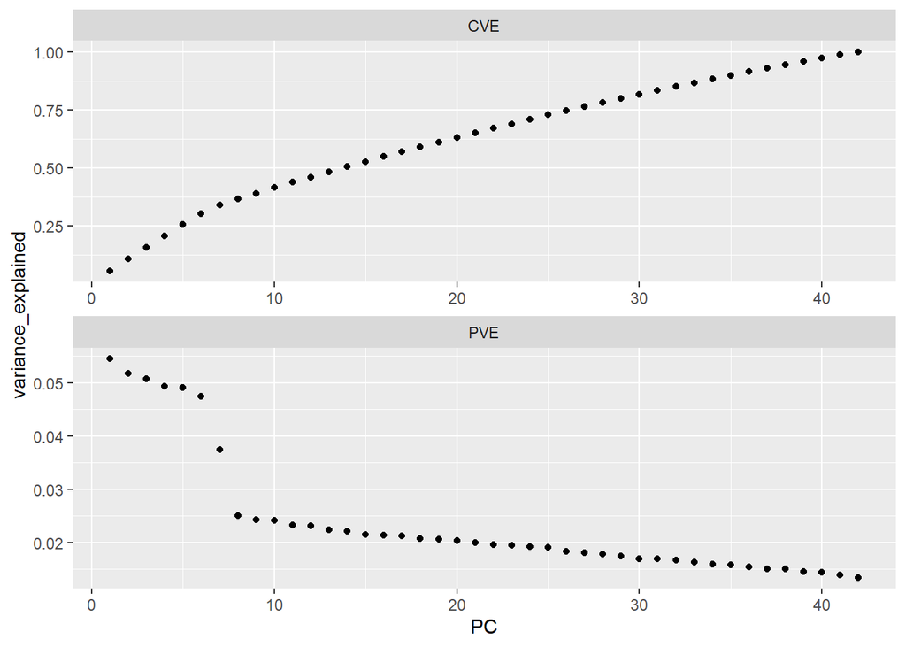

```r
# PC, PVE, CVE 칼럼으로 구성된 데이터프레임으로 생성하기.
pve_cvd <- data.frame(
  PC  = my_pca@model$importance %>% seq_along(),
  PVE = my_pca@model$importance %>% .[2,] %>% unlist(),
  CVE = my_pca@model$importance %>% .[3,] %>% unlist()
  ) %>%
  gather(metric, variance_explained, -PC)

# PVE와 CVE 시각화하기.
pve_cvd %>%
  ggplot(aes(PC, variance_explained)) + # x축 = PC, y축 = variance_explained.
  geom_point() + # 점으로 데이터 포인트 나타내기.
  facet_wrap(~ metric, ncol = 1, scales = "free") # metric을 기준으로 다면출력.
```

```r
# 총 분산의 75퍼센트 이상을 설명하는 데 필요한 주성분의 수.
min(which(pve_cvd$variance_explained >= 0.75))
```

```
## [1] 69
```

- 분산의 비율 조정
  - 사용되는 데이터와 그 용도에 따라 달라질 수 있음.
  - 주성분을 탐색적/기술적 목적으로 사용할 경우, 분산의 비율을 더 낮출 수 있음.
  - 주성분을 모형훈련을 위한 예측변수 추출의 목적으로 사용할 경우, 분산의 비율을 더 높일 수 있음.

### (3) 스크리 플롯(scree plot) 준거

- 스크리 플롯(scree plot)
  - 개별 주성분의 고윳값 또는 PVE를 보여줌.
  - 형태: 대부분의 스크리 플롯은 좌측 상단에서 시작하여 가파르게 하락하며 어느 시점에 가면 평평해지는 형태를 나타냄.
  - 특징
    - 첫 주성분은 총 분산의 상당 부분을 설명해주며, 그 다음 소수의 주성분들은 그보다 적은 부분을 그리고 나머지 주성분들은 극히 일부의 분산만을 설명해줌.
- 스크리 플롯 준거
  - 주성분 곡선이 “팔꿈치”처럼 급격히 꺾이는 부분을 찾는 데 목적이 있음. 곡선이 평평해지기 직전의 모든 주성분을 선택!
  - `my_basket` 데이터셋에서는 8개에 해당.

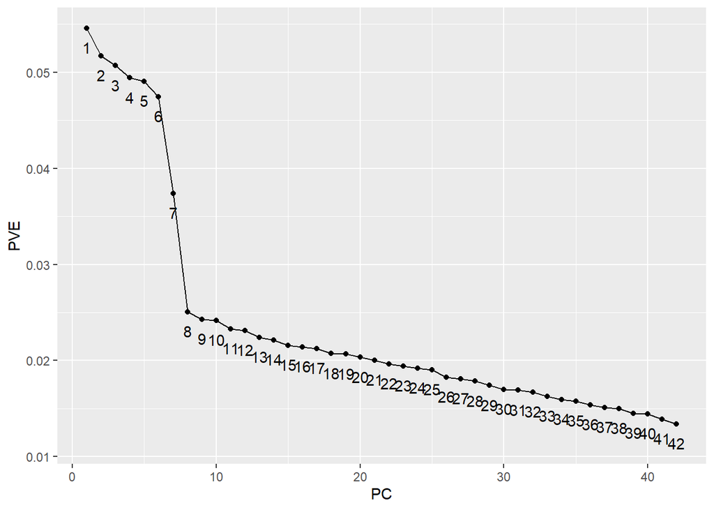

```r
# PC와 PVE 칼럼으로 구성된 데이터프레임 생성하기.
scree_pc <- data.frame(
  PC = my_pca@model$importance %>% seq_along,
  PVE = my_pca@model$importance %>% .[2,] %>% unlist()
)

# 스크리 플롯 생성하기.
scree_pc %>%
  ggplot(aes(PC, PVE, group = 1, label = PC)) + # x축 = PC, y축 = PVE, group = 선을 하나만 생성, label = PC 번호(1-42)를 레이블로 취함.
  geom_point() +
  geom_line() +
  geom_text(nudge_y = -.002) # 아랫쪽으로 .002만큼 떨어진 곳에 텍스트 넣기.
```

# 2. 비지도학습 II: 군집분석 - 위계적 군집분석(hierarchical clustering)

- 정의: 데이터셋에 존재하는 집단들을 파악하는 방법으로, 군집들에 위계를 만들어냄으로써 미리 군집의 수를 지정하지 않아됨.
- 장점: 덴드로그램(dendrogram)이라는 나무 형태의 그래프를 사용하여 결과를 쉽게 시각화할 수 있음.

**[그림 1] 덴드로그램의 사례**

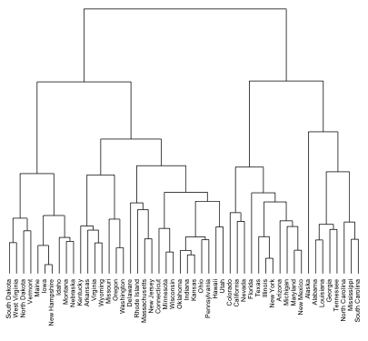

## (1) 준비사항

- 모형의 단순화를 위해 34개의 수치형 예측변수만 사용. 만약 범주형 및 서열형 변수를 사용할 경우, 더미/원핫 인코딩을 통해 수치형 변수로 변환해주면 됨.

```r
# 모형수립 과정에 사용되는 주요 패키지.
library(tidyverse) # 데이터 조작 및 시각화용.
library(tidymodels) # 데이터 전처리 및 모형 훈련용.
library(cluster) # 군집화 모형 수립립용.
library(factoextra) # 군집분석 결과 시각화용.
# 시범용 데이터셋
library(AmesHousing)
ames_scale <- make_ames() %>%
  select_if(is.numeric) %>%  # 수치형 변수만 선택하기.
  select(-Sale_Price) %>%    # 결과변수 제거하기.
  mutate_all(as.double) %>%  # 수치형 변수 double 유형으로 바꾸기.
  scale()                    # 모든 변수 표준화하기.
```

## (2) 위계적 군집분석 알고리즘

### 1) 위계적 군집분석의 유형

- 응집형 군집분석(agglomerative clustering)
  - AGNES(AGglomerative NESting): 상향식(bottom-up)으로 작동. 즉 개별 관찰값은 초기에 하나의 요소로 구성된 군집(single-element cluster)으로 간주.
  - 알고리즘의 각 단계에서, 가장 유사한(거리가 짧은) 두 개의 군집끼리 조합을 이루어 하나의 더 큰 군집(마디[nodes])을 생성.
  - 상기 절차는 모든 관찰값이 하나의 큰 군집(뿌리[root])의 일원이 될 때까지 반복됨.
  - 작은 군집들을 파악하는 데 유리.
- 분리형 위계적 군집분석(divisive hierarchical clustering)
  - DIANA (DIvise ANAlysis): 하향식(top-down)으로 작동. AGNES와 정반대.
  - 뿌리(모든 관찰값이 속해 있는 하나의 큰 군집)에서 시작.
  - 알고리즘의 각 단계에서, 현재의 군집이 가장 이질적인(거리가 먼) 두 개의 군집으로 분리됨.
  - 상기 절차는 모든 관찰값이 자신만의 군집에 속할 때까지 반복됨.
  - 큰 군집들을 파악하는 데 유리.

**[그림 2] 응집형(AGNES) vs. 분리형(DIANA) 군집분석**

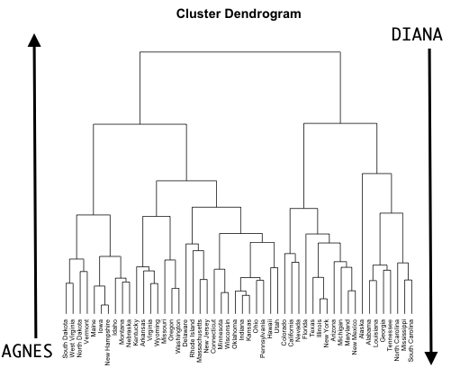

- 두 관찰값 간 거리 측정법
  - 관찰값을 일군의 집단으로 분류하려면 한 쌍의 관찰값 간 거리 또는 (비)유사성을 계산하는 방법이 필요.
  - 군집분석에서는 거리 측정법 선택이 특히 중요
    - 두 관찰값($x_a$와 $x_b$) 간의 유사성을 어떻게 계산할 것인지를 정의.
    - 군집의 모양과 크기를 결정.
  - 방법
    - 유클리드 거리(Euclidean distances)
      - 직선으로 표현되는 거리.
      - 이상치에 매우 민감. 이상치 존재 시, 한쪽으로 편포된 군집결과를 낳음.
      - 예측변수들이 가우시안 분포(Gaussian distribution)를 따를 경우, 유클리드 거리 사용이 이상적.
      - 예측변수들이 정규성을 유의미하게 위반하거나 이상치의 존재에 민감하게 반응하지 않기를 원한다면 맨해튼이나 가워 거리를 추천.
      - 일반적으로 기본값.
    - 맨해튼 거리(Manhattan distances).
    - 상관 기반 거리(correlation-based distances).
    - 가워 거리(Gower distance): 범주형 및 서열형 변수 포함된 데이터셋에 주로 사용.
    - 코사인 거리(cosine distance): 텍스트 마이닝 분야에서 주로 사용.

**[그림 3] 최단 vs. 최장 vs. 평균 연결법 간 비교**

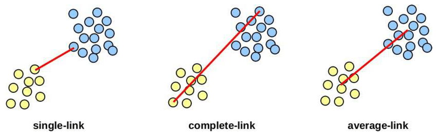

- (관찰값들의) 두 군집 간 거리 측정법
  - 최장 또는 완전 연결법(maximum or complete linkage clustering)
    - 군집 1과 군집 2에 속하는 가장 먼 두 점 사이의 거리를 군집분리 준거로 고려함.
    - 좀 더 압축적 군집을 생성하는 경향이 있음.
  - 최단 또는 단일 연결법(minimum or single linkage clustering)
    - 군집 1과 군집 2에 속하는 가장 가까운 두 점 사이의 거리를 군집분리 준거로 고려함.
    - 다른 군집에 속하는 가장 가까운 두 점 간의 거리를 군집분리 준거로 고려함.
    - 길고 헐거운 군집을 생성하는 경향이 있음.
  - 평균 연결법(mean or average linkage clustering)
    - 군집 1과 군집 2 간의 모든 점들의 쌍 간의 평균 거리를 군집분리 준거로 고려함.
    - 군집들의 압축 정도가 다양한 양상을 나타냄.
  - 중심 연결법(centroid linkage clustering)
    - 군집 1의 중심과 군집 2의 중심 간 거리 계산.
    - 공식
      - $d(i+j,k) = d(\mu_{i+j},\mu_{k}) = \|\mu_{i+j} - \mu_{k} \|^2$, $\mu_{i+j} = \frac{n_{i}\mu_i+n_{j}\mu_j}{n_{i}+n_{j}}$
      - $d(i+j,k)$: 군집 $i$와 $j$가 합쳐진 새로운 군집 $i+j$와 군집 $k$ 간 거리.
      - $\mu_{i+j}$: 새로운 군집 $i+j$에 대해 가중평균(weighted average)을 이용하여 얻은 중심.
      - $n_i$ = 군집 $i$의 관찰값 개수, $n_j$ = 군집 $j$의 관찰값 개수.
  - 워드의 최소분산 방법(Ward’s minimum variance method)
    - 군집 1과 군집 2 간의 유사성을, 두 군집이 합쳐졌을 때 발생하는 오차 제곱합(error sum of squares, ESS)의 증가분을 바탕으로 측정.
    - 총 군집-내 분산을 최소화하는 방식으로 군집 간의 유사성 측정.
    - 각 단계마 가장 군집-간 거리가 짧은 군집 쌍끼리 합쳐짐.
    - 이상치에 덜 민감.
    - 좀 더 압축적 군집을 생성하는 경향이 있음.
    - 비슷한 크기의 군집끼리 묶어주는 경향이 있음.
    - 공식
      - $d(i+j,k) = d(\mu_{i+j},\mu_{k}) = \frac{\|\mu_{i+j} - \mu_{k} \|^2}{\frac{1}{n_i}+\frac{1}{n_j}}$
      - 중심 연결법과 유사. 분자는 같고, 분모만 다름.
  - 선호 연결법
    - AGNES: 최장 연결법, 워드 방법.
    - DIANA: 평균 연결법과 매우 유사한 최대 평균 거리(maximum average dissimilarity) 기반 방법을 바탕으로 군집 분리.

**[그림 4] 위계적 군집분석의 유형**

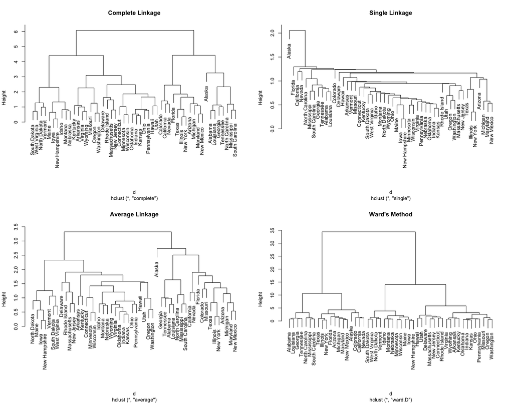

## (3) 위계적 군집분석 실행하기

### 1) 응집형 위계적 군집분석

#### A. R 내장 함수

- `dist()`
  - 설명: R 내장 거리 계산용 함수.
  - 주요 논항
    - 데이터프레임.
    - `method`: 관찰값 간 거리 계산법. “euclidean”, “maximum”, “manhattan”, “canberra”, “binary”, “minkowski” 등의 선택지가 있음.
- `hclust()`
  - 설명: R 내장 응집형 위계적 군집분석 함수.
  - 주요 논항
    - `dist()` 객체.
    - `method`: 군집 간 거리 측정법. “ward.D”, “ward.D2”, “single”, “complete”, “average”, “mcquitty”, “median”, “centroid” 등의 선택지가 있음.

```r
# 난수 고정하기.
set.seed(123)

# 군집 간 거리 행렬 계산하기
d <- dist(ames_scale, method = "euclidean")

# 최장 연결법을 사용하여 위계적 군집분석 수행하기.
hc1 <- hclust(d, method = "complete" )
```

#### B. **cluster** 패키지 함수

- `agnes()`
  - 설명: **cluster** 패키지의 응집형 위계적 군집분석 함수.
  - 특징
    - 응집계수(agglomerative coefficient, AC)를 산출해줌.
      - 1에 가까울수록 좀 더 균형잡힌 군집구조를 시사함. 반면에 0에 가까울수록 편포적 형태의 군집구조를 시사함.
      - 관찰값 $n$이 증가할수록 증가하는 경향이 있으므로, 관찰값 수에 큰 차이가 있는 데이터셋끼리는 비교하지 않는 것이 좋음.
  - 주요 논항
    - 데이터프레임.
    - `stand`: 표준화 여부. `TRUE` 또는 `FALSE`의 선택지가 있음.
    - `metric`: 관찰값 간 거리 계산법. “euclidean”, “manhattan” 등의 선택지가 있음.
    - `method`: 군집 간 거리 측정법. “average”, “single”, “complete”, “ward”, “weighted”, “flexible”, “gaverage” 등의 선택지가 있음. 기본값은 “average”.

```r
# 난수 고정하기.
set.seed(123)

# 최장 연결법을 사용하여 위계적 군집분석 수행하기.
hc2 <- agnes(ames_scale, stand = T, metric = "euclidean", method = "complete")

# 응집계수.
hc2$ac
```

```
## [1] 0.9826076
```

- 완전탐색(grid search)
  - 가장 강력한 군집구조를 생성할 수 있는 위계적 군집화 방법 찾기.
  - 시간이 다소 소요됨.

```r
# 완전탐색을 통해 평가할 군집화 방법
m <- c( "average", "single", "complete", "ward")
names(m) <- c("average", "single", "complete", "ward") # 벡터 m의 각 요소에 이름 부여하기.

# 응집계수 계산용 함수.
ac <- function(x) {
  agnes(ames_scale, method = x)$ac
}

# 각 군집화 방법의 응집계수 비교하기.
map_dbl(m, ac)
```

```
##   average    single  complete      ward
## 0.9139303 0.8712890 0.9267750 0.9766577
```

### 2) 분리형 위계적 군집분석

- `diana()`
  - 설명: **cluster** 패키지의 분리형 위계적 군집분석 함수.
  - 특징
    - `agnes()`와 유사하나, 응집형 연결법을 제공하지 않음. $\Rightarrow$ `method` 논항이 없음!
    - 분리계수(divisive coefficient, DC)를 산출해줌: 1에 가까울수록 집단을 잘 구분해줌을 의미.
  - 주요 논항
    - 데이터프레임.
    - `stand`: 표준화 여부. `TRUE` 또는 `FALSE`의 선택지가 있음.
    - `metric`: 관찰값 간 거리 계산법. “euclidean”, “manhattan” 등의 선택지가 있음.

```r
# 난수 고정하기.
set.seed(123)

# 분리형 위계적 군집분석 수행하기.
hc4 <- diana(ames_scale, stand = T, metric = "euclidean")

# 분리계수.
hc4$dc
```

```
## [1] 0.9808944
```

## (4) 최적의 군집 수 결정하기

- 팔꿈치 방법(elbow method)
  - 군집분할 방법의 기본개념은 총 군집-내 분산(총 군집 내 제곱합[total within-cluster sum of square, WSS])이 최소화되는 방향으로 군집을 형성하는 것.
  - 공식: $minimize\Bigg(\sum^k_{k=1}W(C_k)\Bigg)$ $\Rightarrow$ $C_k$는 $k$ 번째 군집을, $W(C_k)$는 군집-내 분산을 가리킴.
  - 총 군집-내 분산은 군집의 압축도 측정치를 제공하는데, 이는 가능한 한 작으면 작을수록 좋음.
  - 알고리즘의 절차
    1. $k$ 값을 달리해가며 군집분석 방법(예를 들면, 위계적 군집분석) 실행.
    2. 각각의 $k$에 대해 총 군집-내 분산 계산.
    3. $k$개의 군집 수별로 총 군집-내 분산 커브를 그림.
    4. 플롯에서 가파르게 꺾이는 지점이 일반적으로 적절한 군집의 개수로 고려됨.
- 실루엣 방법(silhouette method)
  - 군집화가 얼마나 잘되었는지 그 질을 측정하는 방법. 즉 각 관찰값이 얼마나 해당 군집에 잘 들어가 있는지를 판단. 실루엣 값이 높을수록 군집화가 잘되었음을 의미.
  - 실루엣 계수(silhouette coefficient): $S(i) = \frac{b(i)- a(i)}{max\{a(i), b(i)\}}$
    - $b(i)$: 점 $i$와 다른 군집 내 모든 점 간의 가장 작은 평균 거리.
    - $a(i)$: 점 $i$와 자신이 속한 군집 내 다른 모든 점 간의 평균 거리.
    - 예시: A, B, C 세 군집이 있고, $i$는 군집 C에 속한다고 가정. $b(i)$를 얻으려면, $i$와 군집 A의 모든 점들 간의 평균 거리와 $i$ 및 군집 B의 모든 점들 간의 평균 거리를 측정하고 가장 작은 결과값을 취하면 됨.
  - 실루엣 계수 해석
    - 해당 데이터셋의 실루엣 계수 = 개별 데이터 포인트의 실루엣 계수의 평균. $\Rightarrow$ 개별 데이터 포인트들이 자신의 군집에 정확하게 할당되어 있는지 여부를 알려줌.
    - 1에 가까울수록 표본이 이웃 군집들과 멀리 떨어져 있음을 의미.
    - 0에 가까울수록 두 이웃 군집 간에 걸쳐 있음을 의미.
    - 마이너스 값이면 샘플이 잘못된 군집에 할당되어 있음을 의미.
- 갭 통계치(gap static)
  - Tibshirani, Walther & Hastie (2001) 논문에서 제안.
  - 총 군집-내 분산, 즉 군집 압축도(cluster compactness)를 군집 개수 $k$를 달리하며 아무런 명확한 군집이 없는 영준거 분포(null reference distribution)와 비교하는 것.
  - 준거 데이터셋은 몬테카를로(Monte Carlo) 시뮬레이션을 통한 부트스트래핑 표집과정을 통해 생성됨.
  - 공식
    - $Gap_n(k) = E^*_n{log(W_k)} - log(W_k)$: $E^*_n$는 표본 크기 $n$일 때 영준거 분포를 통해 기대되는 분산. 갭 통계치는 실제 $W_k$ 값이 영가설일 때 예측된 값으로부터 얼마나 멀리 떨어져 있는지를 측정.
    - $W_k = \sum\limits_{r=1}^k\frac{1}{2n_r}{D_r}$.
    - 기호설명: $d$가 유클리드 거리 제곱이라면, $W_k$는 군집 평균 주변의 군집-내 제곱합을 의미. $n$은 표본의 크기.
    - 최적의 군집 수는 $log(W_k)$가 이 영준거와 최대한 멀리 떨어져 있도록 해주는 $k$ 값이 될 것.
- **factoextra** 패키지의 `fviz_nbclust()` 함수
  - 기능: 다양한 방법을 사용하여 최적의 군집 수를 찾아주며 그 결과를 시각화해줌.
  - 주요 논항
    - 데이터프레임.
    - `FUN`: kmeans, **cluster** 패키지의 pam, clara, fanny, hcut 등의 선택지가 있음.
    - `method`: “silhouette”, “wss”, “gap_stat” 등의 선택지가 있음.
    - `k.max`: 생성 가능한 최대 군집 수. 최소 2개 이상이어야 함.
    - `nboot`: 부트스트래핑 표집의 횟수. 갭 통계치 선택 시에만 사용.

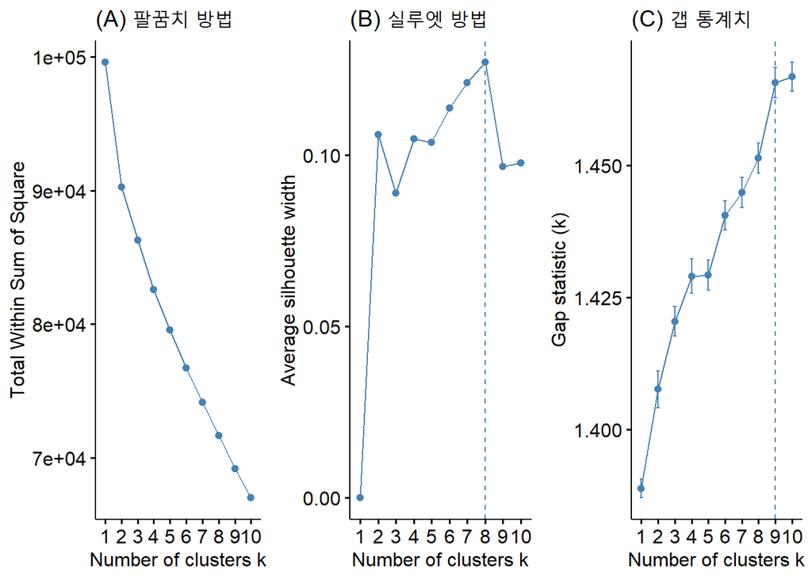

```r
# 최적의 군집 개수 찾기 및 시각화.
p1 <- fviz_nbclust(ames_scale, FUN = hcut, method = "wss", # 팔꿈치 방법 사용.
                   k.max = 10) +
  ggtitle("(A) 팔꿈치 방법")
p2 <- fviz_nbclust(ames_scale, FUN = hcut, method = "silhouette", # 실루엣 방법 사용.
                   k.max = 10) +
  ggtitle("(B) 실루엣 방법")
p3 <- fviz_nbclust(ames_scale, FUN = hcut, method = "gap_stat", # 갭 통계치 사용.
                   k.max = 10) +
  ggtitle("(C) 갭 통계치")

# 최적의 군집 개수 플롯 3개 다면출력.
library(gridExtra)
grid.arrange(p1, p2, p3, nrow = 1)
```

## (5) 덴드로그램 그리기

- 덴드로그램의 이해
  - 군집 간의 관계를 시각화.
  - 덴드로그램의 최종 마디(잎 마디)는 하나의 관찰값(`Ames` 데이터셋에서는 개별 주택)에 해당.
  - 나무의 위로 올라갈수록 서로 비슷한 관찰값끼리 한 가지로 합쳐짐.
- **factoextra** 패키지의 `fviz_dend()` 함수
  - 군집분석 객체: hclust, agnes, diana, hcut, hkmeans, HCPC 등의 선택지가 있음.
  - `k`: 나무를 몇 개의 집단/군집으로 자를 것인가?
  - `h`: 덴드로그램을 어느 정도의 높이에서 자를 것인가? `k`가 `h`를 덮어씀.
  - `k_colors`, `palette`: 군집을 표현하는 데 사용되는 색상 벡터. k개의 색상이 포함되어야 함. `palette`로는 “grey”, “RdBu”, “Blues”, “npg”, “aaas”, “lancet”, “jco”, “ucscgb”, “uchicago”, “simpsons”, “rickandmorty” 등의 선택지가 있음.
  - `show_labels`: `TRUE`이면 잎/최종 레이블을 보여줌.
  - `color_labels_by_k`: k별로 자동으로 덴드로그램 선에 색을 부여함.
  - `type`: 덴드로그램의 모양. “rectangle”, “triangle”, “circular”, “phylogenic” 등의 선택지가 있음.
  - `rect`: `TRUE`이면 군집 주위에 사각형 테두리를 추가해줌.
  - `rect_border`, `rect_lty`: 사각형 테두리의 색상과 선 유형 지정.
  - `rect_fill`:`TRUE`이면 사각형 테두리 안을 채워줌.
  - `horiz`: `TRUE`이면 덴드로그램을 뒤집어 수평으로 보여줌.
  - `main`, `xlab`, `ylab`: 덴드로그램의 주제목, x축 레이블, y축 레이블.
  - `sub`: 덴드로그램의 하위제목.
  - `cex`: 텍스트 레이블의 크기.

```r
# Ames 데이터셋으로 덴드로그램 그리기.
hc5 <- hclust(d, method = "ward.D2") # R 내장 함수 hclust()로 위계적 군집분석 수행.
dend_plot <- fviz_dend(hc5) # fviz_dend() 함수에 군집분석 객체 투입.
dend_data <- attr(dend_plot, "dendrogram") # 플롯 정보 중에서 dendrogram 관련 정보만 추출.
dend_cuts <- cut(dend_data, h = 8)# 덴드로그램을 높이 8에서 잘라냄.
dend_cuts$lower[1:10] # 상위 10개 덴드로그램.
```

```
## [[1]]
## 'dendrogram' leaf '661', at height 0
##
## [[2]]
## 'dendrogram' with 2 branches and 8 members total, at height 7.426552
##
## [[3]]
## 'dendrogram' with 2 branches and 2 members total, at height 5.221699
##
## [[4]]
## 'dendrogram' leaf '1362', at height 0
##
## [[5]]
## 'dendrogram' with 2 branches and 4 members total, at height 5.38979
##
## [[6]]
## 'dendrogram' leaf '2667', at height 0
##
## [[7]]
## 'dendrogram' with 2 branches and 5 members total, at height 6.994623
##
## [[8]]
## 'dendrogram' leaf '2046', at height 0
##
## [[9]]
## 'dendrogram' leaf '2195', at height 0
##
## [[10]]
## 'dendrogram' with 2 branches and 8 members total, at height 6.608869
```

```r
dend_cuts$lower[[2]] # 가지 2개, 군집 8개, 높이 7.426552인 덴드로그램.
```

```
## 'dendrogram' with 2 branches and 8 members total, at height 7.426552
```

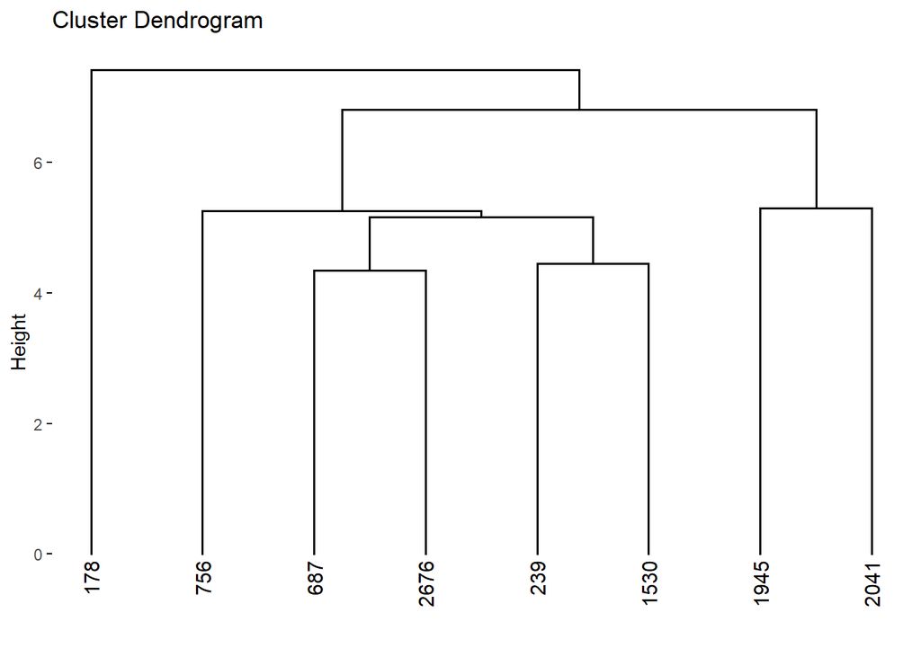

```r
fviz_dend(dend_cuts$lower[[2]]) # fviz_dend() 함수에 높이 8에서 잘라낸 덴드로그램 투입.
```

```r
# hcut() 함수로 덴드로그램 자르기.
sub_grp <- hcut(ames_scale, hc_func = "agnes", k = 8, stand = T) # 군집 수 8개로 설정.
sub_grp$cluster # 개별 관찰값이 어느 군집에 속하는지 보여줌.
```

[output not shown]

[output cut: 65 more lines]

```r
sub_grp$size # 군집당 할당된 관찰값의 수.
```

```
## [1] 1363  567  650   36  123  156   24   11
```

- **factoextra** 패키지의 `fviz_dend()` 함수로 8개 군집(`k = 8`)을 하이라이트하기:

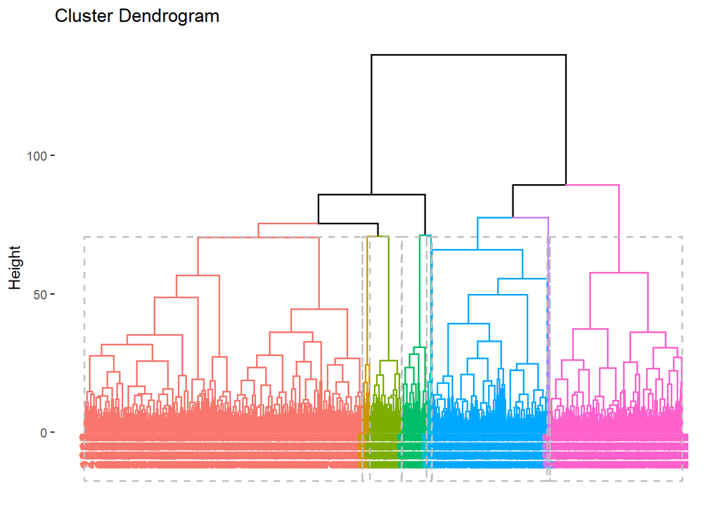

```r
# 덴드로그램 완전체 그리기: 수직으로 보여주기.
fviz_dend(
  sub_grp,
  rect = TRUE
  )
```

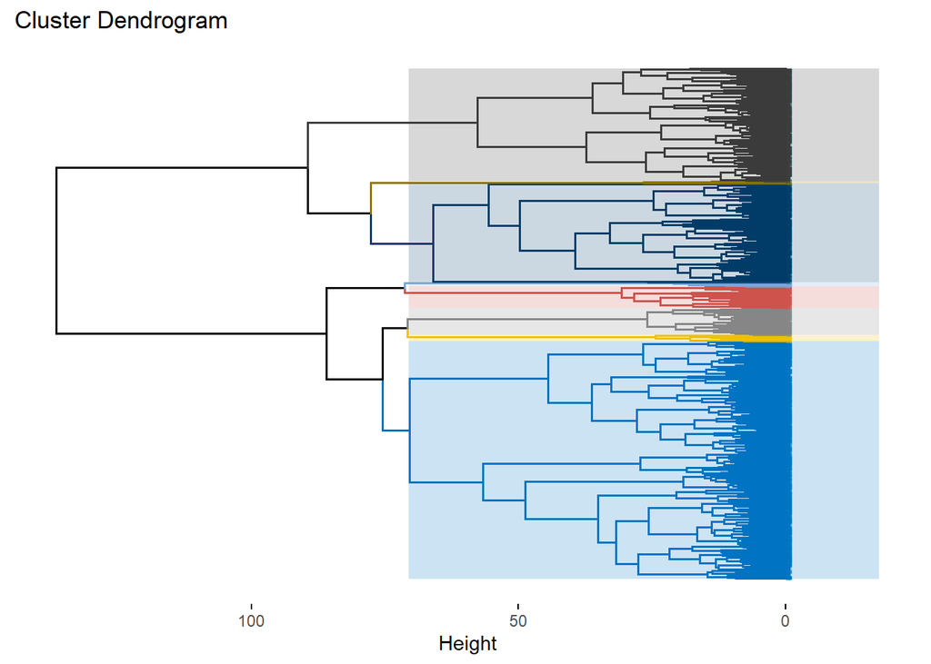

```r
# 덴드로그램 완전체 그리기: 수평으로 보여주기.
fviz_dend(
  sub_grp,
  k = 8,
  k_colors = "jco",
  rect = TRUE,
  rect_fill = TRUE,
  rect_border = "jco",
  horiz = TRUE,
  cex = 0.1
  )
```

- 줌인 기능
  - `Ames` 데이터셋의 관찰값이 워낙 많은 탓에 하위군집으로 갈수록 덴드로그램을 제대로 읽어낼 수 없음.
  - 이에 따라 특정 구역/군집을 줌인하여 들여다보고자 할 수 있음.
  - 이때 특정 군집 내에서 어떤 관찰값들 간의 거리가 가장 가까운지 확인할 수 있음.

```r
# Ames 데이터셋으로 덴드로그램 그리기.
dend_plot <- fviz_dend(hc5)                # 덴드로그램 완전체 그리기.
dend_data <- attr(dend_plot, "dendrogram") # fviz_dend() 함수에 군집분석 객체 투입.
dend_cuts.1 <- cut(dend_data, h = 70.5)      # 덴드로그램을 높이 70.5에서 잘라냄.
dend_cuts.1$lower[1:10] # 상위 10개 덴드로그램.
```

```
## [[1]]
## 'dendrogram' with 2 branches and 24 members total, at height 21.0145
##
## [[2]]
## 'dendrogram' with 2 branches and 123 members total, at height 30.69486
##
## [[3]]
## 'dendrogram' with 2 branches and 1363 members total, at height 70.37253
##
## [[4]]
## 'dendrogram' with 2 branches and 36 members total, at height 24.42218
##
## [[5]]
## 'dendrogram' with 2 branches and 156 members total, at height 25.89143
##
## [[6]]
## 'dendrogram' with 2 branches and 650 members total, at height 57.68522
##
## [[7]]
## 'dendrogram' with 2 branches and 11 members total, at height 26.61995
##
## [[8]]
## 'dendrogram' with 2 branches and 567 members total, at height 66.00241
##
## [[9]]
## NULL
##
## [[10]]
## NULL
```

```r
dend_cuts.1$lower[[1]] # 가지 2개, 군집 24개, 높이 21.0145인 덴드로그램.
```

```
## 'dendrogram' with 2 branches and 24 members total, at height 21.0145
```

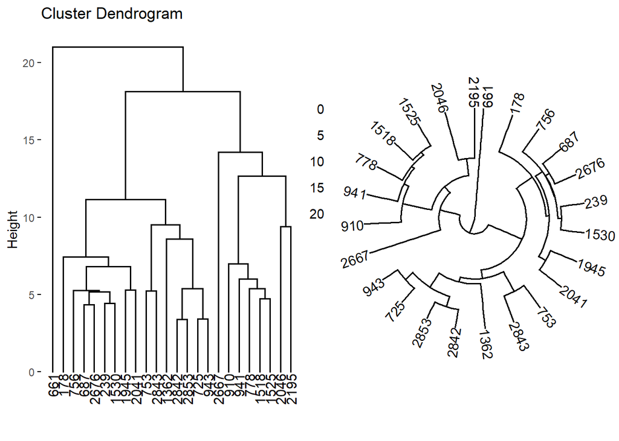

```r
# 하위 덴드로그램 그리기.
p1 <- fviz_dend(dend_cuts.1$lower[[1]]) # 사각형 덴드로그램.
p2 <- fviz_dend(dend_cuts.1$lower[[1]], type = 'circular') # 원형 덴드로그램.

# 두 유형의 덴드로그램 2개 다면출력.
grid.arrange(p1, p2, nrow = 1)
```

# References

Tibshirani, R., Walther, G., & Hastie, T. (2001). Estimating the number of clusters in a data set via the gap statistic. *Journal of the Royal Statistical Society: Series B (Statistical Methodology), 63*(2), 411-423.

[^1]: https://butter-shower.tistory.com/210 에서 인용
[^2]: https://butter-shower.tistory.com/210 에서 인용
[^3]: https://darkpgmr.tistory.com/110 에서 인용
[^4]: https://darkpgmr.tistory.com/110 에서 인용